### Fayruz Kibria CIND 820 April 4 2022

## Imporing the rawdata sheet (sheet 3) from the library.

```r
# Imporing the rawdata sheet (sheet 3) from the library

library(readxl)
library(httr)
#packageVersion("readxl")

url<-'https://archive.ics.uci.edu/ml/machine-learning-databases/00193/CTG.xls'
GET(url, write_disk(tf <- tempfile(fileext = ".xls")))
```

```
## Response [https://archive.ics.uci.edu/ml/machine-learning-databases/00193/CTG.xls]
##   Date: 2022-04-04 20:17
##   Status: 200
##   Content-Type: application/x-httpd-php
##   Size: 1.74 MB
## <ON DISK>  C:\Users\fayru\AppData\Local\Temp\RtmpS6CX7e\file44505e30d6f.xls
```

## read rawdata as a dataframe

```r
# read raw data file in as dataframe

rawdata <- read_excel(tf, 3L)
#str(rawdata)
#head(rawdata)
#tail(rawdata)
```

## dropping incomplete cases, and irrelevant columns after examining head and tail of data

```r
# dropping incomplete cases, and irrelevant columns after examining head and tail of data

library(tidyr)

df1<-rawdata[!complete.cases(rawdata),]
df1<-rawdata %>% drop_na()
df1<- subset (df1, select = -c(FileName,Date,SegFile))
df1<-as.data.frame(df1)
head(df1)
```

```
##     b    e LBE  LB AC FM UC ASTV MSTV ALTV MLTV DL DS DP DR Width Min Max Nmax
## 1 240  357 120 120  0  0  0   73  0.5   43  2.4  0  0  0  0    64  62 126    2
## 2   5  632 132 132  4  0  4   17  2.1    0 10.4  2  0  0  0   130  68 198    6
## 3 177  779 133 133  2  0  5   16  2.1    0 13.4  2  0  0  0   130  68 198    5
## 4 411 1192 134 134  2  0  6   16  2.4    0 23.0  2  0  0  0   117  53 170   11
## 5 533 1147 132 132  4  0  5   16  2.4    0 19.9  0  0  0  0   117  53 170    9
## 6   0  953 134 134  1  0 10   26  5.9    0  0.0  9  0  2  0   150  50 200    5
##   Nzeros Mode Mean Median Variance Tendency A B C D E AD DE LD FS SUSP CLASS
## 1      0  120  137    121       73        1 0 0 0 0 0  0  0  0  1    0     9
## 2      1  141  136    140       12        0 0 0 0 0 0  1  0  0  0    0     6
## 3      1  141  135    138       13        0 0 0 0 0 0  1  0  0  0    0     6
## 4      0  137  134    137       13        1 0 0 0 0 0  1  0  0  0    0     6
## 5      0  137  136    138       11        1 0 1 0 0 0  0  0  0  0    0     2
## 6      3   76  107    107      170        0 0 0 0 0 0  0  0  1  0    0     8
##   NSP
## 1   2
## 2   1
## 3   1
## 4   1
## 5   1
## 6   3
```

## assigning col names, checking for missing data, and data description

```r
# assigning col names, checking for missing data, and data description

library(psych)


names <- c('Tendency', 'A', 'B',    'C',    'D',    'E',    'AD',   'DE',   'LD',   'FS',   'SUSP', 'CLASS', 'NSP')
df1[,names] <- lapply(df1[,names] , factor)

names <- c('AC',    'FM',   'UC',       'DL',   'DS',   'DP',   'DR', 'Nmax', 'Nzeros')
df1[,names] <- lapply(df1[,names] , as.integer)


cat("There are", sum(is.na(df1)), "missing data in the dataset.\n\n")
```

```
## There are 0 missing data in the dataset.
```

```r
describe(df1)
```

```
##           vars    n    mean     sd median trimmed    mad   min    max  range
## b            1 2126  878.44 894.08  538.0  763.43 794.67   0.0 3296.0 3296.0
## e            2 2126 1702.88 930.92 1241.0 1622.78 782.81 287.0 3599.0 3312.0
## LBE          3 2126  133.30   9.84  133.0  133.26  10.38 106.0  160.0   54.0
## LB           4 2126  133.30   9.84  133.0  133.26  10.38 106.0  160.0   54.0
## AC           5 2126    2.72   3.56    1.0    2.05   1.48   0.0   26.0   26.0
## FM           6 2126    7.24  37.13    0.0    1.06   0.00   0.0  564.0  564.0
## UC           7 2126    3.66   2.85    3.0    3.41   2.97   0.0   23.0   23.0
## ASTV         8 2126   46.99  17.19   49.0   46.88  20.76  12.0   87.0   75.0
## MSTV         9 2126    1.33   0.88    1.2    1.22   0.74   0.2    7.0    6.8
## ALTV        10 2126    9.85  18.40    0.0    5.17   0.00   0.0   91.0   91.0
## MLTV        11 2126    8.19   5.63    7.4    7.71   4.60   0.0   50.7   50.7
## DL          12 2126    1.57   2.50    0.0    1.03   0.00   0.0   16.0   16.0
## DS          13 2126    0.00   0.06    0.0    0.00   0.00   0.0    1.0    1.0
## DP          14 2126    0.13   0.46    0.0    0.00   0.00   0.0    4.0    4.0
## DR          15 2126    0.00   0.00    0.0    0.00   0.00   0.0    0.0    0.0
## Width       16 2126   70.45  38.96   67.5   68.63  46.70   3.0  180.0  177.0
## Min         17 2126   93.58  29.56   93.0   92.97  40.03  50.0  159.0  109.0
## Max         18 2126  164.03  17.94  162.0  163.11  16.31 122.0  238.0  116.0
## Nmax        19 2126    4.07   2.95    3.0    3.76   2.97   0.0   18.0   18.0
## Nzeros      20 2126    0.32   0.71    0.0    0.17   0.00   0.0   10.0   10.0
## Mode        21 2126  137.45  16.38  139.0  138.49  14.83  60.0  187.0  127.0
## Mean        22 2126  134.61  15.59  136.0  135.51  14.83  73.0  182.0  109.0
## Median      23 2126  138.09  14.47  139.0  138.72  14.83  77.0  186.0  109.0
## Variance    24 2126   18.81  28.98    7.0   12.38   8.90   0.0  269.0  269.0
## Tendency*   25 2126    2.32   0.61    2.0    2.37   0.00   1.0    3.0    2.0
## A*          26 2126    1.18   0.38    1.0    1.10   0.00   1.0    2.0    1.0
## B*          27 2126    1.27   0.45    1.0    1.22   0.00   1.0    2.0    1.0
## C*          28 2126    1.02   0.16    1.0    1.00   0.00   1.0    2.0    1.0
## D*          29 2126    1.04   0.19    1.0    1.00   0.00   1.0    2.0    1.0
## E*          30 2126    1.03   0.18    1.0    1.00   0.00   1.0    2.0    1.0
## AD*         31 2126    1.16   0.36    1.0    1.07   0.00   1.0    2.0    1.0
## DE*         32 2126    1.12   0.32    1.0    1.02   0.00   1.0    2.0    1.0
## LD*         33 2126    1.05   0.22    1.0    1.00   0.00   1.0    2.0    1.0
## FS*         34 2126    1.03   0.18    1.0    1.00   0.00   1.0    2.0    1.0
## SUSP*       35 2126    1.09   0.29    1.0    1.00   0.00   1.0    2.0    1.0
## CLASS*      36 2126    4.51   3.03    4.0    4.27   2.97   1.0   10.0    9.0
## NSP*        37 2126    1.30   0.61    1.0    1.15   0.00   1.0    3.0    2.0
##            skew kurtosis    se
## b          0.83    -0.54 19.39
```

[output cut: 21 more lines]

```
## Median    -0.48     0.66  0.31
## Variance   3.22    15.08  0.63
## Tendency* -0.31    -0.66  0.01
## A*         1.66     0.75  0.01
## B*         1.02    -0.96  0.01
## C*         6.09    35.10  0.00
## D*         4.82    21.26  0.00
## E*         5.15    24.54  0.00
## AD*        1.89     1.58  0.01
## DE*        2.36     3.56  0.01
## LD*        4.11    14.91  0.00
## FS*        5.27    25.82  0.00
## SUSP*      2.81     5.89  0.01
## CLASS*     0.38    -1.23  0.07
## NSP*       1.85     2.08  0.01
```

# deescription of categorical variables

```r
# deescription of categorical variables

library(SmartEDA)
ExpCTable(df1,Target=NULL,clim=5,nlim=15,round=2,bin=NULL,per=F)
```

```
##    Variable Valid Frequency Percent CumPercent
## 1  Tendency    -1       165    7.76       7.76
## 2  Tendency     0      1115   52.45      60.21
## 3  Tendency     1       846   39.79     100.00
## 4  Tendency TOTAL      2126      NA         NA
## 5         A     0      1742   81.94      81.94
## 6         A     1       384   18.06     100.00
## 7         A TOTAL      2126      NA         NA
## 8         B     0      1547   72.77      72.77
## 9         B     1       579   27.23     100.00
## 10        B TOTAL      2126      NA         NA
## 11        C     0      2073   97.51      97.51
## 12        C     1        53    2.49     100.00
## 13        C TOTAL      2126      NA         NA
## 14        D     0      2045   96.19      96.19
```

[output cut: 59 more lines]

```r
ExpCustomStat(df1,Cvar=c("Tendency","A","B","C","D","E","AD","DE","LD","FS","SUSP","CLASS", "NSP"),gpby=FALSE)
```

```
##     Level Group_by Count  Prop
##  1:     1 Tendency   846 39.79
##  2:     0 Tendency  1115 52.45
##  3:    -1 Tendency   165  7.76
##  4:     0        A  1742 81.94
##  5:     1        A   384 18.06
##  6:     0        B  1547 72.77
##  7:     1        B   579 27.23
##  8:     0        C  2073 97.51
##  9:     1        C    53  2.49
## 10:     0        D  2045 96.19
## 11:     1        D    81  3.81
## 12:     0        E  2054 96.61
## 13:     1        E    72  3.39
## 14:     0       AD  1794 84.38
```

[output cut: 23 more lines]

## plotting all raw variable histogram

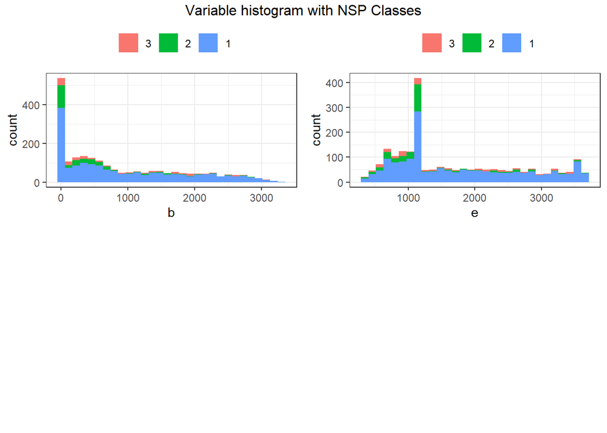

```r
# plotting all raw variable histogram

library(ggplot2)
library(gridExtra)

theme_set(
  theme_bw() +
    theme(legend.title=element_blank())+
    theme(legend.position = "top")
  )

temp<-df1

# b e
p=list()
namess<-c('b','e')
for (i in 1:length(namess)){
  p[[i]] <- ggplot(temp, aes_string(x = namess[i])) +
  geom_histogram(aes(fill=factor(NSP, levels=c("3", "2", "1"))))
}
grid.arrange(grobs=p,ncol=2, nrow=2, top = "Variable histogram with NSP Classes")
```

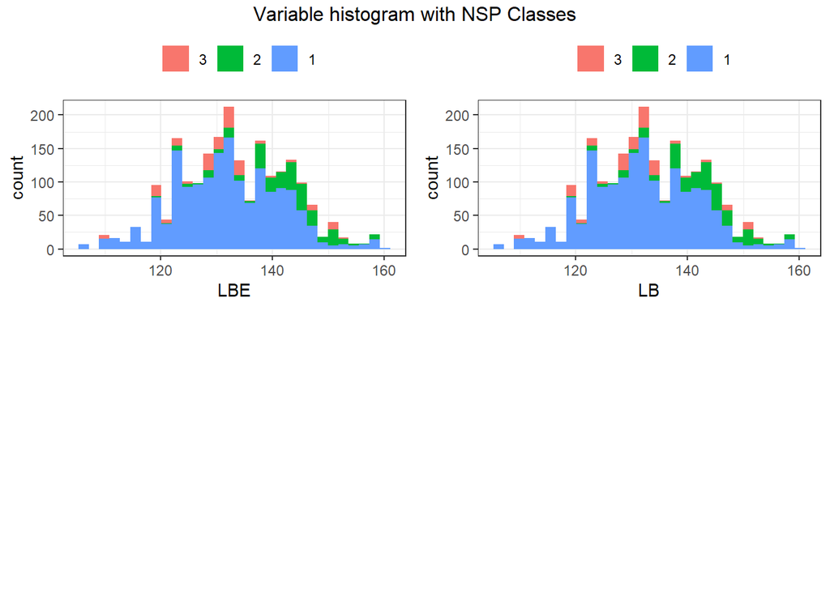

```r
#LBE    LB
p=list()
namess<-c('LBE','LB')
for (i in 1:length(namess)){
  p[[i]] <- ggplot(temp, aes_string(x = namess[i])) +
  geom_histogram(aes(fill=factor(NSP, levels=c("3", "2", "1"))))
}
grid.arrange(grobs=p,ncol=2, nrow=2, top = "Variable histogram with NSP Classes")
```

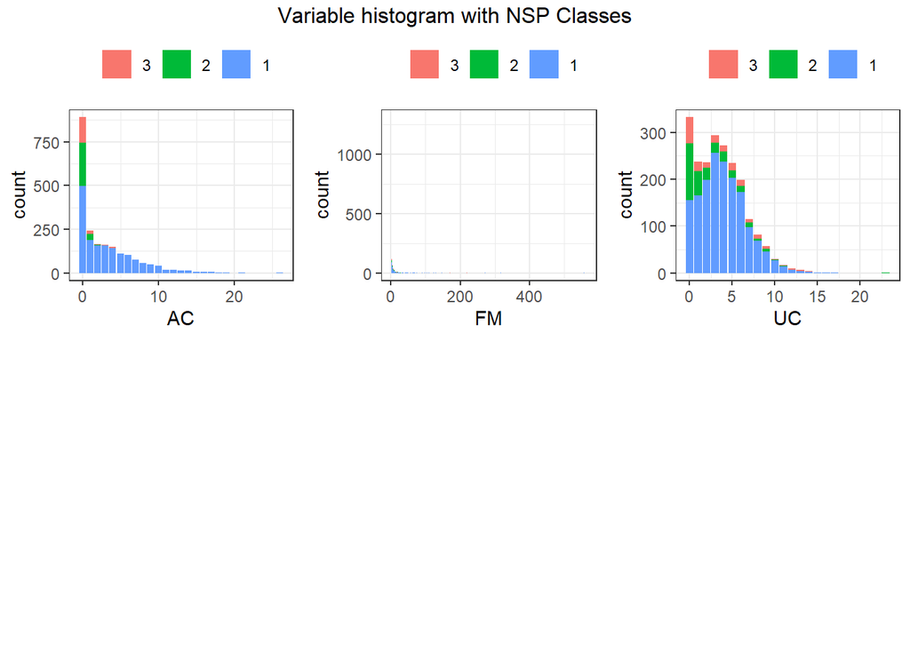

```r
#AC FM  UC
p=list()
namess<-c('AC', 'FM',   'UC')
for (i in 1:length(namess)){
  p[[i]] <- ggplot(temp, aes_string(x = namess[i])) +
  geom_bar(aes(fill=factor(NSP, levels=c("3", "2", "1"))))
}
grid.arrange(grobs=p,ncol=3, nrow=2, top = "Variable histogram with NSP Classes")
```

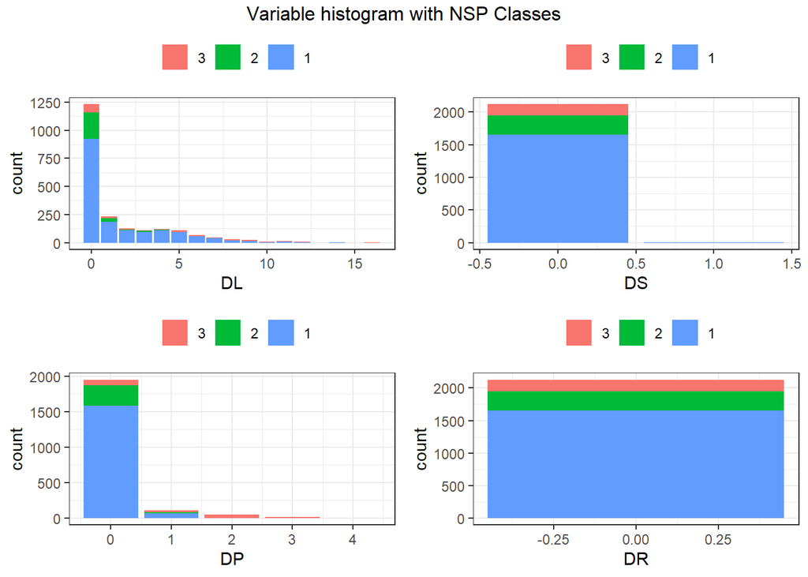

```r
#   DL  DS  DP  DR
p=list()
namess<-c(  'DL',   'DS',   'DP',   'DR')
for (i in 1:length(namess)){
  p[[i]] <- ggplot(temp, aes_string(x = namess[i])) +
  geom_bar(aes(fill=factor(NSP, levels=c("3", "2", "1"))))
}
grid.arrange(grobs=p,ncol=2, nrow=2, top = "Variable histogram with NSP Classes")
```

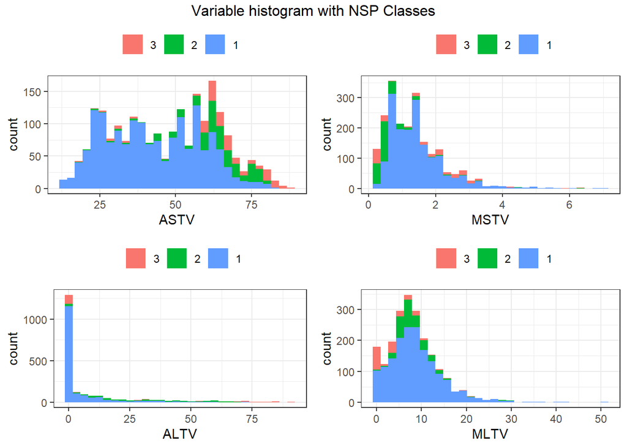

```r
#ASTV   MSTV    ALTV    MLTV
p=list()
namess<-c('ASTV',   'MSTV', 'ALTV', 'MLTV')
for (i in 1:length(namess)){
  p[[i]] <- ggplot(temp, aes_string(x = namess[i])) +
  geom_histogram(aes(fill=factor(NSP, levels=c("3", "2", "1"))))
}
grid.arrange(grobs=p,ncol=2, nrow=2, top = "Variable histogram with NSP Classes")
```

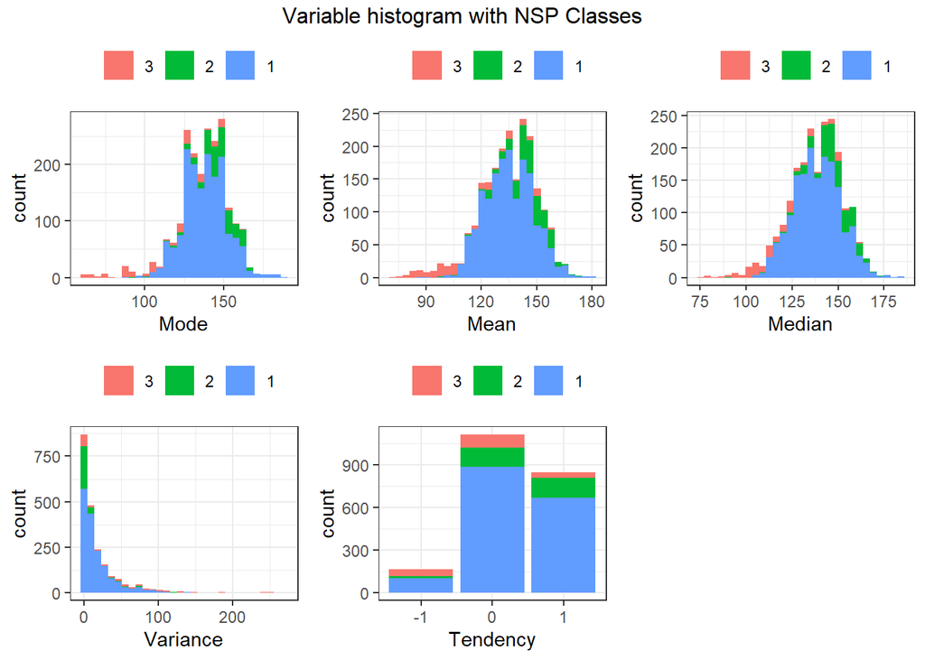

```r
# Mode  Mean    Median  Variance Tendency
p=list()
namess<-c('Mode',   'Mean', 'Median',   'Variance','Tendency')
for (i in 1:length(namess)){
  if(i < length(namess)){
  p[[i]] <- ggplot(temp, aes_string(x = namess[i])) +
  geom_histogram(aes(fill=factor(NSP, levels=c("3", "2", "1"))))
  }else{
  p[[i]] <- ggplot(temp, aes_string(x = namess[i])) +
  geom_bar(aes(fill=factor(NSP, levels=c("3", "2", "1"))))
  }
}
grid.arrange(grobs=p,ncol=3, nrow=2, top = "Variable histogram with NSP Classes")
```

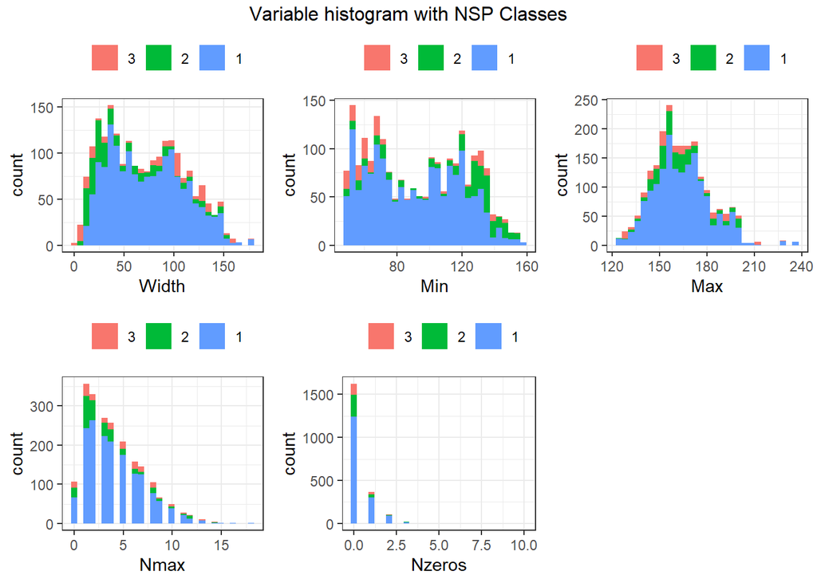

```r
# Width Min Max     Nmax    Nzeros
p=list()
namess<-c('Width',  'Min',  'Max','Nmax',   'Nzeros' )
for (i in 1:length(namess)){
  p[[i]] <- ggplot(temp, aes_string(x = namess[i])) +
  geom_histogram(aes(fill=factor(NSP, levels=c("3", "2", "1"))))
}
grid.arrange(grobs=p,ncol=3, nrow=2, top = "Variable histogram with NSP Classes")
```

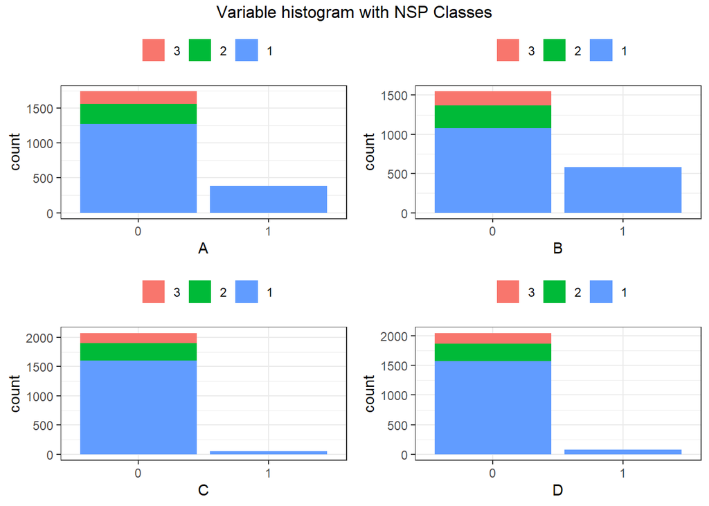

```r
#A  B   C   D
p=list()
namess<-c('A',  'B',    'C',    'D')
for (i in 1:length(namess)){
  p[[i]] <- ggplot(temp, aes_string(x = namess[i])) +
  geom_bar(aes(fill=factor(NSP, levels=c("3", "2", "1"))))
}
grid.arrange(grobs=p,ncol=2, nrow=2, top = "Variable histogram with NSP Classes")
```

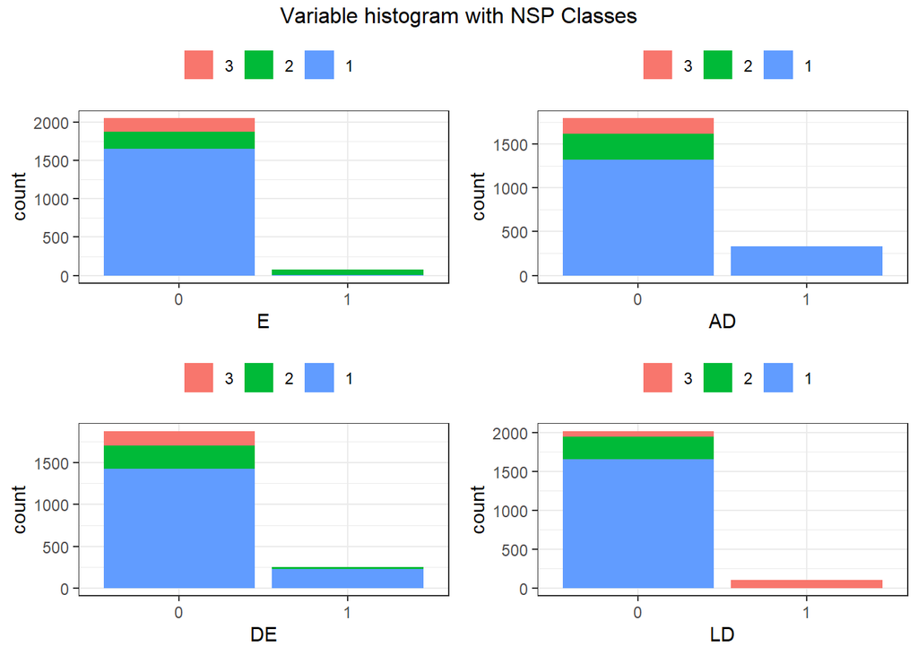

```r
#   E   AD  DE  LD
p=list()
namess<-c('E',  'AD',   'DE',   'LD')
for (i in 1:length(namess)){
  p[[i]] <- ggplot(temp, aes_string(x = namess[i])) +
  geom_bar(aes(fill=factor(NSP, levels=c("3", "2", "1"))))
}
grid.arrange(grobs=p,ncol=2, nrow=2, top = "Variable histogram with NSP Classes")
```

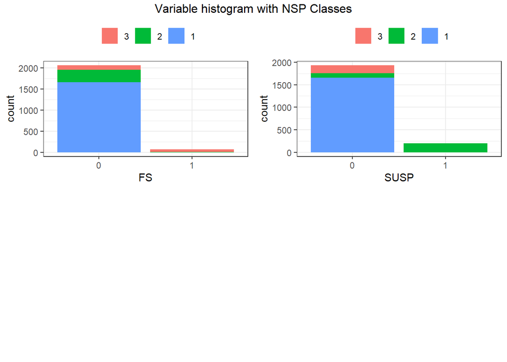

```r
#   FS  SUSP
p=list()
namess<-c('FS', 'SUSP')
for (i in 1:length(namess)){
  p[[i]] <- ggplot(temp, aes_string(x = namess[i])) +
  geom_bar(aes(fill=factor(NSP, levels=c("3", "2", "1"))))
}
grid.arrange(grobs=p,ncol=2, nrow=2, top = "Variable histogram with NSP Classes")
```

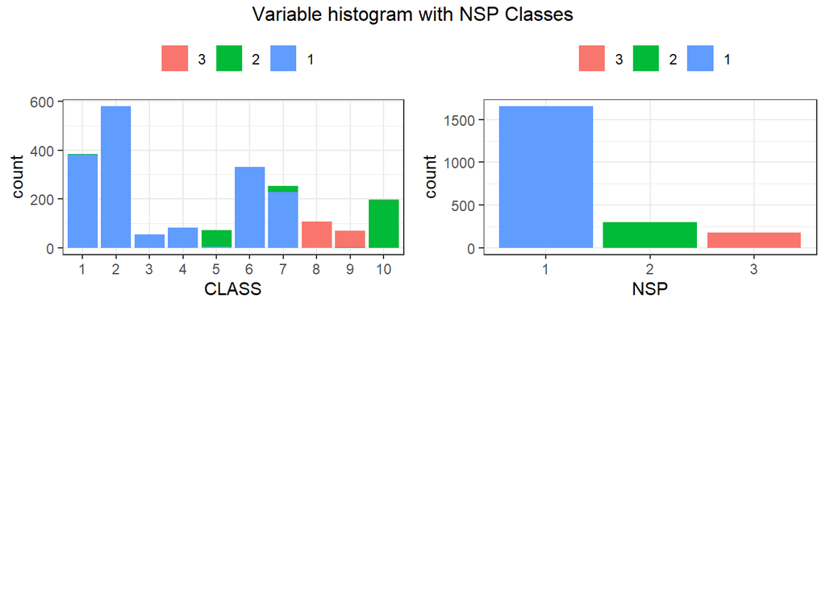

```r
# CLASS NSP
p=list()
namess<-c( 'CLASS' ,    'NSP')
for (i in 1:length(namess)){
  p[[i]] <- ggplot(temp, aes_string(x = namess[i])) +
  geom_bar(aes(fill=factor(NSP, levels=c("3", "2", "1"))))
}
grid.arrange(grobs=p,ncol=2, nrow=2, top = "Variable histogram with NSP Classes")
```

## checking if LBE and LB are exact duplicate columns in the dataset

```r
# checking if there are exact duplicate columns in the dataset

dup <- ifelse(df1$LBE > df1$LB, 1,ifelse(df1$LBE < df1$LB, 1, 0))
paste0("There are ",sum(dup)," items that are different in the LB anf LBE columns.")
```

```
## [1] "There are 0 items that are different in the LB anf LBE columns."
```

## dropping the variable LBE because it is exact copy of the LB variable

```r
# dropping the variable LBE because it is exact copy of the LB variable

df2<- subset (df1, select = -c(DR, LBE))
#str(df2)
```

## calculating nPoints the length of record length variable from end and start instance numbers

## normalizing the recording length sensitive variables, adding them to the data set and dropping original cols

```r
# calculating nPoints the length of record length variable from end and start instance numbers
# normalizing the recording length sensitive variables, adding them to the data set and dropping original cols

library(dplyr)
df3 <- df2 %>% mutate(nPoints = e - b)

df3 <- df3 %>% mutate(nAC = AC/nPoints)
df3 <- df3 %>% mutate(nFM = FM/nPoints)
df3 <- df3 %>% mutate(nUC = UC/nPoints)
df3 <- df3 %>% mutate(nDL = DL/nPoints)
df3 <- df3 %>% mutate(nDS = DS/nPoints)
df3 <- df3 %>% mutate(nDP = DP/nPoints)


#df4 <- subset (df3, select = -c(b, e,  AC, FM, UC, DL, DS, DP))#, A, B, C, D, E, AD, DE, LD, FS, SUSP))

#str(df4)
```

## plotting recording length n points

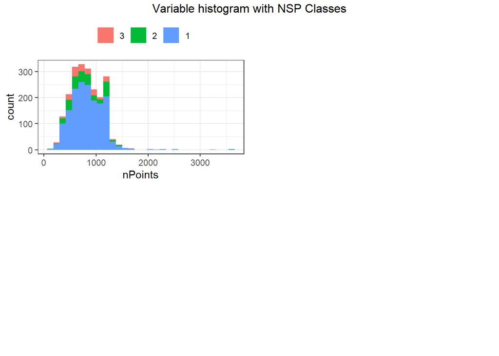

```r
# plotting n points and recording-length-normalized data

theme_set(
  theme_bw() +
    theme(legend.title=element_blank())+
    theme(legend.position = "top")
  )

temp<-df3

# nPoints
p=list()
namess<-c('nPoints')
for (i in 1:length(namess)){
  p[[i]] <- ggplot(temp, aes_string(x = namess[i])) +
  geom_histogram(aes(fill=factor(NSP, levels=c("3", "2", "1"))))
}
grid.arrange(grobs=p,ncol=2, nrow=2, top = "Variable histogram with NSP Classes")
```

## saving normalized and not normalized dataframe for analysis in python

```r
# saving normalized and not normalized dataframe for analysis in python

library(tidyverse)
min_max_norm <- function(x) {
    (x - min(x)) / (max(x) - min(x))
  }

norm_df_0<- subset (df3, select = -c(b, e,  AC, FM, UC, DL, DS, DP))
norm_df_1 <- as.data.frame(sapply(norm_df_0 %>% select(where(is.numeric)), min_max_norm))
norm_df <- as.data.frame(cbind(norm_df_1, norm_df_0 %>% select(where(is.factor))))

# describeBy(norm_df, group=norm_df$NSP)
#str(norm_df)

write.csv(norm_df,"norm_df.csv", row.names = FALSE)

no_norm_df_0<- subset (df3, select = -c(b,  e,  nAC,    nFM,    nUC,    nDL,    nDS,    nDP))
no_norm_df<-as.data.frame(cbind(no_norm_df_0 %>% select(where(is.numeric)) ,no_norm_df_0 %>% select(where(is.factor)) ))

#str(no_norm_df)
write.csv(no_norm_df,"no_norm_df.csv", row.names = FALSE)
```

##plotting percentage distribution of NSP class by functionally grouped machine read variables

```r
library(Hmisc)
```

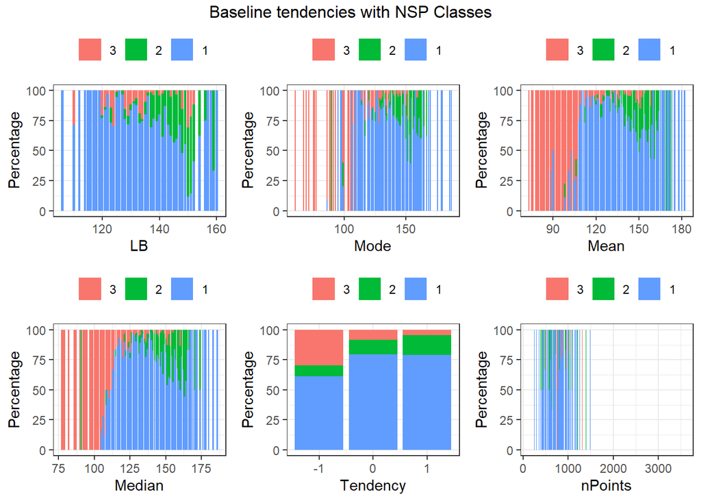

```r
library(dplyr)
library(ggplot2)
library(gridExtra)
library(scales)
library(rlang)
theme_set(
  theme_bw() +
    theme(legend.title=element_blank())+
    theme(legend.position = "top")
  )

temp<-no_norm_df

# 'LB','Mode', 'Mean', 'Median', 'Tendency'
p=list()
namess<-c('LB','Mode', 'Mean', 'Median', 'Tendency', 'nPoints')

i=1
for (var in namess){

new_temp = temp %>%
  select(sym(var), NSP)%>%
      group_by(.data[[var]], NSP) %>%
        mutate(test = n()) %>%
          distinct(.data[[var]], NSP, test) %>%
            group_by(.data[[var]]) %>%
                mutate(pct = test/sum(test)*100)

p[[i]] <- ggplot(new_temp, aes(x= .data[[var]], y = pct)) +
              geom_bar(aes(fill=factor(NSP, levels=c("3", "2", "1"))), stat = "identity")+
              labs(x = var, y = "Percentage",
                fill = "NSP Class")

i=i+1

}

grid.arrange(grobs=p,ncol=3, nrow=2, top = "Baseline tendencies with NSP Classes")
```

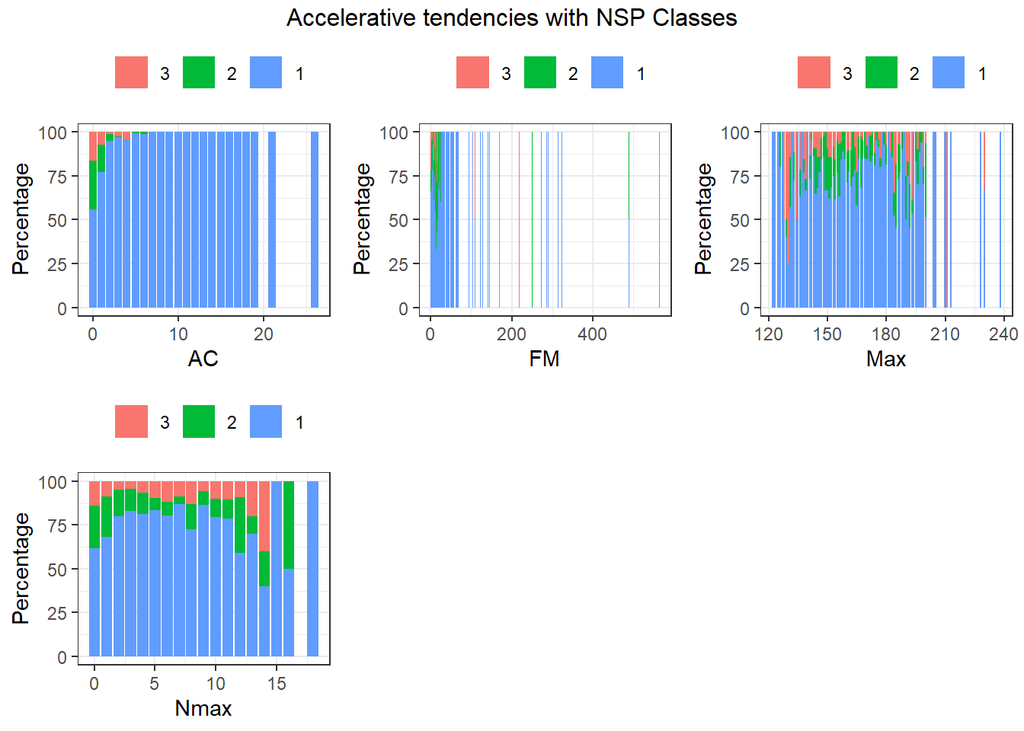

```r
# 'AC', 'FM',   'Max', 'Nmax'
p=list()
namess<-c('AC', 'FM',   'Max', 'Nmax')
i=1
for (var in namess){

new_temp = temp %>%
  select(sym(var), NSP)%>%
      group_by(.data[[var]], NSP) %>%
        mutate(test = n()) %>%
          distinct(.data[[var]], NSP, test) %>%
            group_by(.data[[var]]) %>%
                mutate(pct = test/sum(test)*100)


p[[i]] <- ggplot(new_temp, aes(x= .data[[var]], y = pct)) +
              geom_bar(aes(fill=factor(NSP, levels=c("3", "2", "1"))), stat = "identity")+
              labs(x = var, y = "Percentage",
                fill = "NSP Class")

i=i+1

}
grid.arrange(grobs=p,ncol=3, nrow=2, top = "Accelerative tendencies with NSP Classes")
```

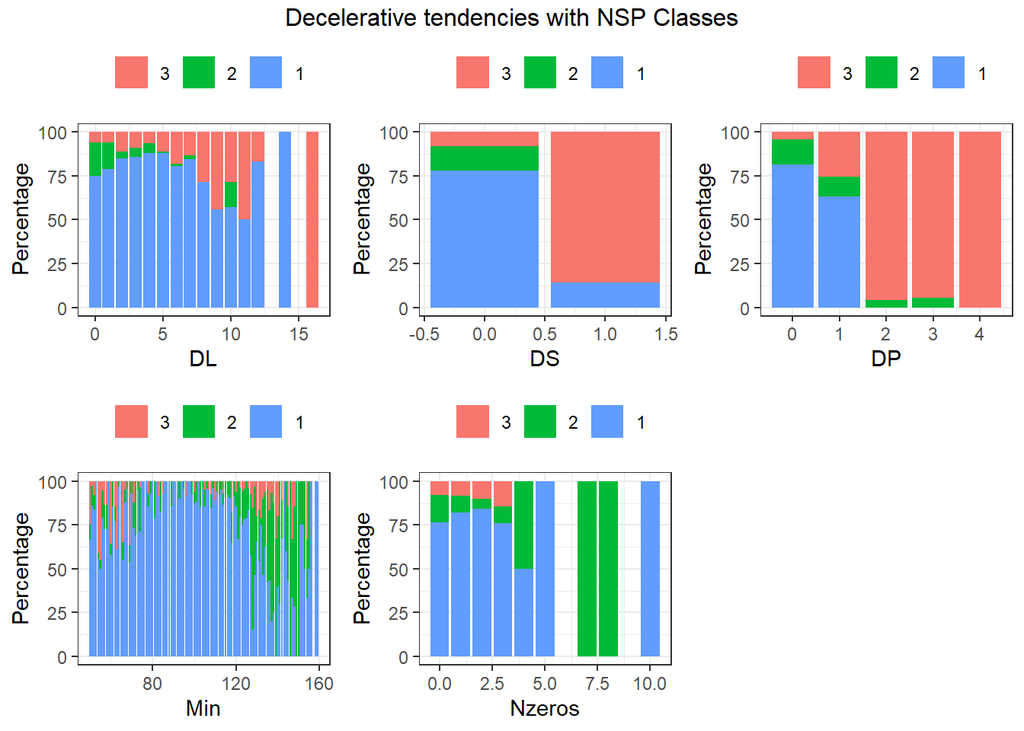

```r
#   'DL',   'DS',   'DP',   'Min', 'Nzeros'
p=list()
namess<-c('DL', 'DS',   'DP',   'Min', 'Nzeros')
i=1
for (var in namess){

new_temp = temp %>%
  select(sym(var), NSP)%>%
      group_by(.data[[var]], NSP) %>%
        mutate(test = n()) %>%
          distinct(.data[[var]], NSP, test) %>%
            group_by(.data[[var]]) %>%
                mutate(pct = test/sum(test)*100)

p[[i]] <- ggplot(new_temp, aes(x= .data[[var]], y = pct)) +
              geom_bar(aes(fill=factor(NSP, levels=c("3", "2", "1"))), stat = "identity")+
              labs(x = var, y = "Percentage",
                fill = "NSP Class")

i=i+1

}
grid.arrange(grobs=p,ncol=3, nrow=2, top = "Decelerative tendencies with NSP Classes")
```

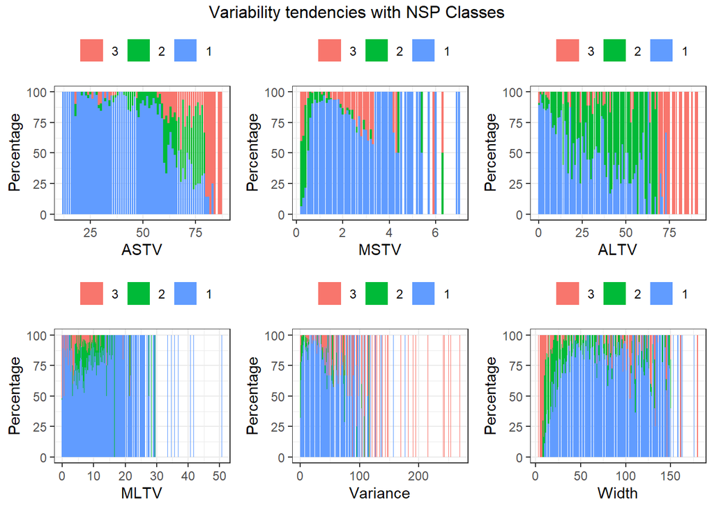

```r
#'ASTV',    'MSTV', 'ALTV', 'MLTV', 'Variance','Width'
p=list()
namess<-c('ASTV',   'MSTV', 'ALTV', 'MLTV', 'Variance','Width')
i=1
for (var in namess){

new_temp = temp %>%
  select(sym(var), NSP)%>%
      group_by(.data[[var]], NSP) %>%
        mutate(test = n()) %>%
          distinct(.data[[var]], NSP, test) %>%
            group_by(.data[[var]]) %>%
                mutate(pct = test/sum(test)*100)

p[[i]] <- ggplot(new_temp, aes(x= .data[[var]], y = pct)) +
              geom_bar(aes(fill=factor(NSP, levels=c("3", "2", "1"))), stat = "identity")+
              labs(x = var, y = "Percentage",
                fill = "NSP Class")

i=i+1

}
grid.arrange(grobs=p,ncol=3, nrow=2, top = "Variability tendencies with NSP Classes")
```

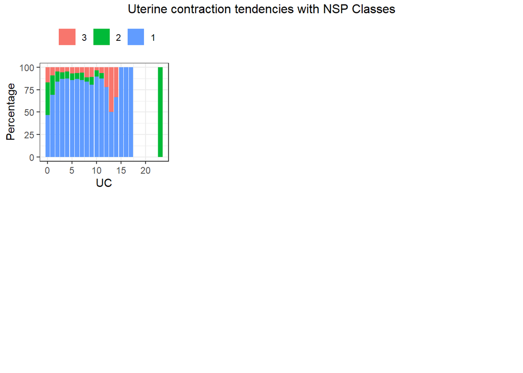

```r
#'UC'
p=list()
namess<-c('UC')
i=1
for (var in namess){

new_temp = temp %>%
  select(sym(var), NSP)%>%
      group_by(.data[[var]], NSP) %>%
        mutate(test = n()) %>%
          distinct(.data[[var]], NSP, test) %>%
            group_by(.data[[var]]) %>%
                mutate(pct = test/sum(test)*100)



p[[i]] <- ggplot(new_temp, aes(x= .data[[var]], y = pct)) +
              geom_bar(aes(fill=factor(NSP, levels=c("3", "2", "1"))), stat = "identity")+
              labs(x = var, y = "Percentage",
                fill = "NSP Class")

i=i+1

}
grid.arrange(grobs=p,ncol=3, nrow=2, top = "Uterine contraction tendencies with NSP Classes")
```

## plotting pairwise colleration for machine variables grouped by function

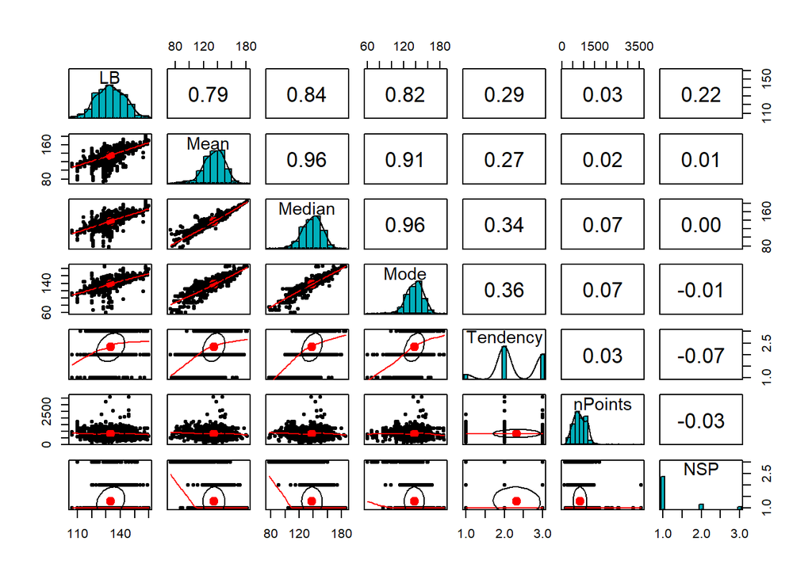

```r
library(psych)

dataframe0<-no_norm_df

pairs.panels(dataframe0[,c('LB','Mean', 'Median', 'Mode', 'Tendency', 'nPoints','NSP')],
             bg=c("red","yellow","blue")[dataframe0$NSP],
             method = "spearman", # correlation method
             hist.col = "#00AFBB",
             density = TRUE,  # show density plots
             ellipses = TRUE # show correlation ellipses
             )
```

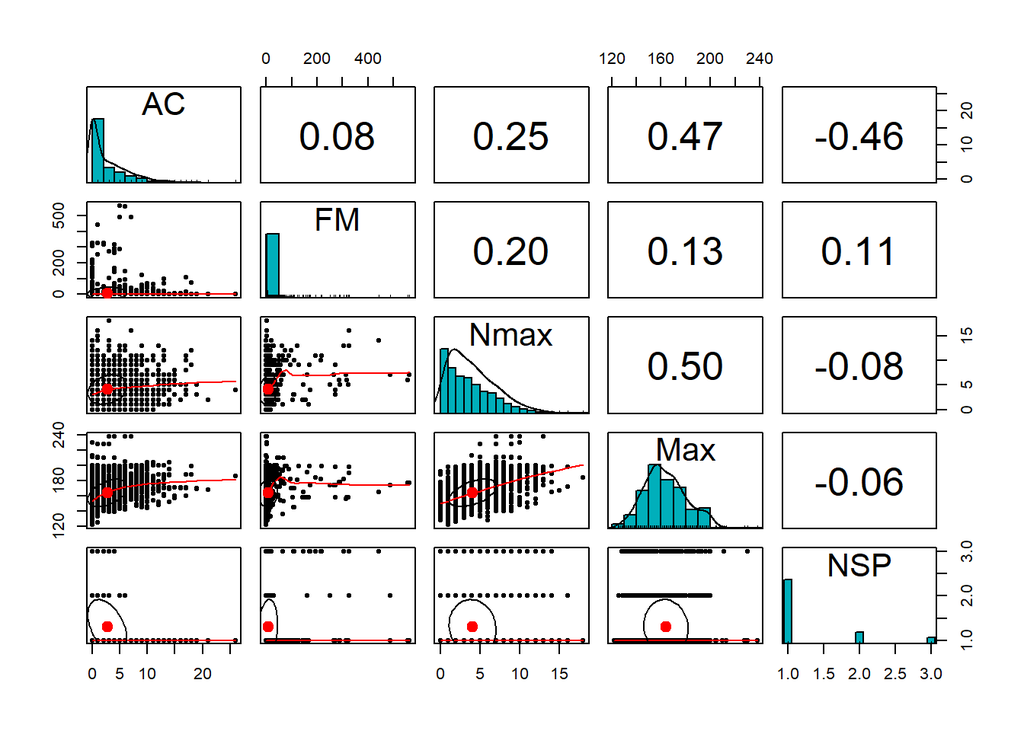

```r
pairs.panels(dataframe0[,c('AC','FM','Nmax','Max','NSP')],
             method = "spearman", # correlation method
             hist.col = "#00AFBB",
             density = TRUE,  # show density plots
             ellipses = TRUE # show correlation ellipses
             )
```

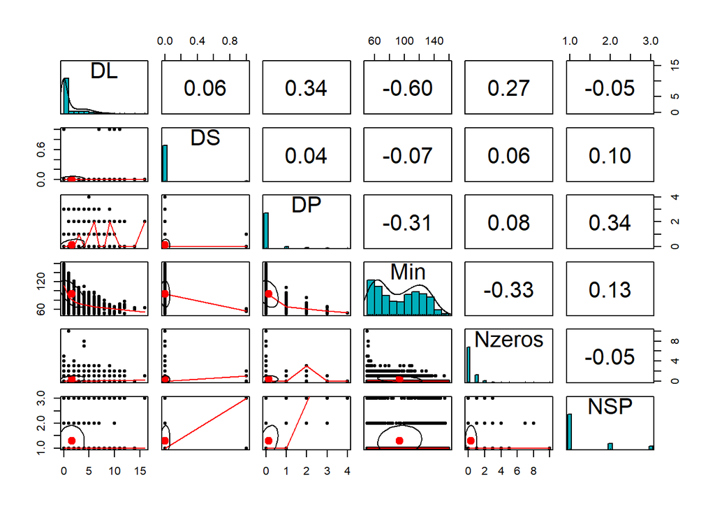

```r
pairs.panels(dataframe0[,c('DL','DS','DP','Min','Nzeros','NSP')],
             method = "spearman", # correlation method
             hist.col = "#00AFBB",
             density = TRUE,  # show density plots
             ellipses = TRUE # show correlation ellipses  5,6,7,13,
             )
```

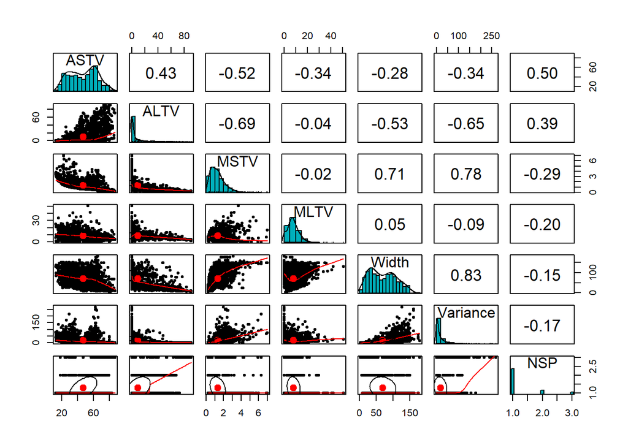

```r
pairs.panels(dataframe0[,c('ASTV','ALTV','MSTV','MLTV','Width','Variance','NSP')],
             method = "spearman", # correlation method
             hist.col = "#00AFBB",
             density = TRUE,  # show density plots
             ellipses = TRUE # show correlation ellipses  5,6,7,13,
             )
```

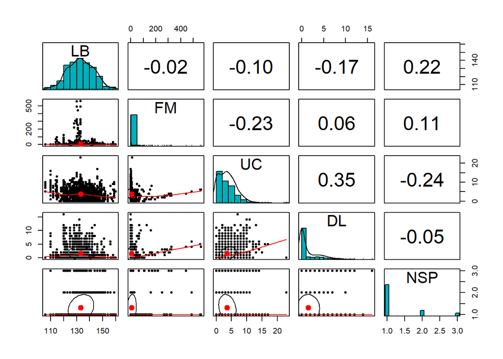

```r
pairs.panels(dataframe0[,c('LB','FM','UC','DL','NSP')],
             method = "spearman", # correlation method
             hist.col = "#00AFBB",
             density = TRUE,  # show density plots
             ellipses = TRUE # show correlation ellipses  5,6,7,13,
             )
```

#### Exploring the correlation between the attributes other than class attribute

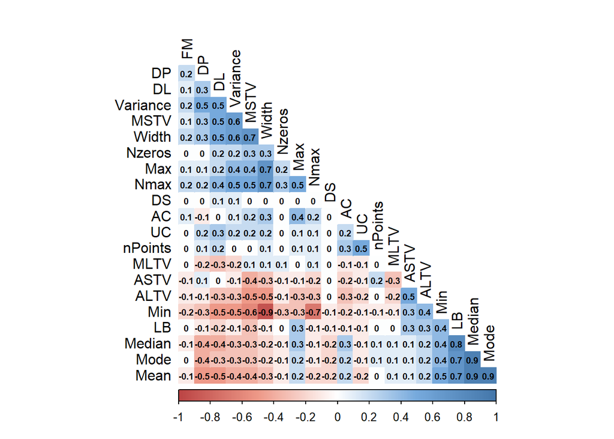

```r
# correlation plot of all the min max normalized numerical variables

library(corrplot)
col <- colorRampPalette(c("#BB4444", "#EE9988", "#FFFFFF", "#77AADD", "#4477AA"))
corrplot(round(cor(select_if(no_norm_df, is.numeric)),1), method="color", col=col(200),
         type="lower", order="hclust",
         addCoef.col = "black", # Add coefficient of correlation
         tl.col="black", tl.srt=90, number.cex= .6,#Text label color and rotation
         # hide correlation coefficient on the principal diagonal
         diag=FALSE
         )
```

## spearmans correlation for machine data

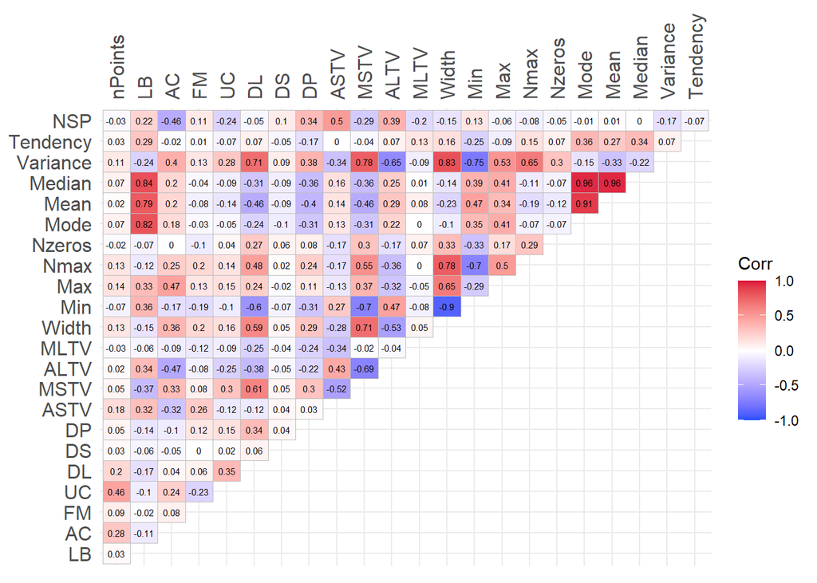

```r
library(ggcorrplot)


machine_names<-c('nPoints','LB','AC',   'FM',   'UC',   'DL',   'DS',   'DP',   'ASTV', 'MSTV', 'ALTV', 'MLTV', 'Width', 'Min', 'Max',  'Nmax', 'Nzeros',   'Mode', 'Mean', 'Median',   'Variance', 'Tendency','NSP')

machine_data<-subset (no_norm_df, select = machine_names)
names <- c('Tendency','NSP')
machine_data[,names] <- as.data.frame(lapply(machine_data[,names] , as.integer))

morpho_names<-c('A' ,'B',   'C',    'D',    'E',    'AD',   'DE',   'LD',   'FS',   'SUSP',     'CLASS','NSP')

morpho_data<-no_norm_df[,morpho_names]

names <- c('A'  ,'B',   'C',    'D',    'E',    'AD',   'DE',   'LD',   'FS',   'SUSP',     'CLASS','NSP')
morpho_data[,names] <- lapply(morpho_data[,names] , as.integer)

#pairwise.complete.obs spearman
model.matrix(~0+., data=machine_data) %>%
  cor(use="pairwise.complete.obs", method = 'spearman') %>%
  ggcorrplot(show.diag = F, type="upper", lab=TRUE, lab_size=2, tl.srt = 90, colors = c( "#1F51FF", "white","#DC143C"))+
  scale_x_discrete(position='top')+
  theme(aspect.ratio=3/4, axis.text.x.top = element_text(angle = 90,hjust = 0,vjust = 0.5))
```

```r
#model.matrix to one-hot encode all non-numeric variables. This is quite different than calculating Cramér's V as it will consider your factor as separate variables
```

## spearmans correlation for morphological data

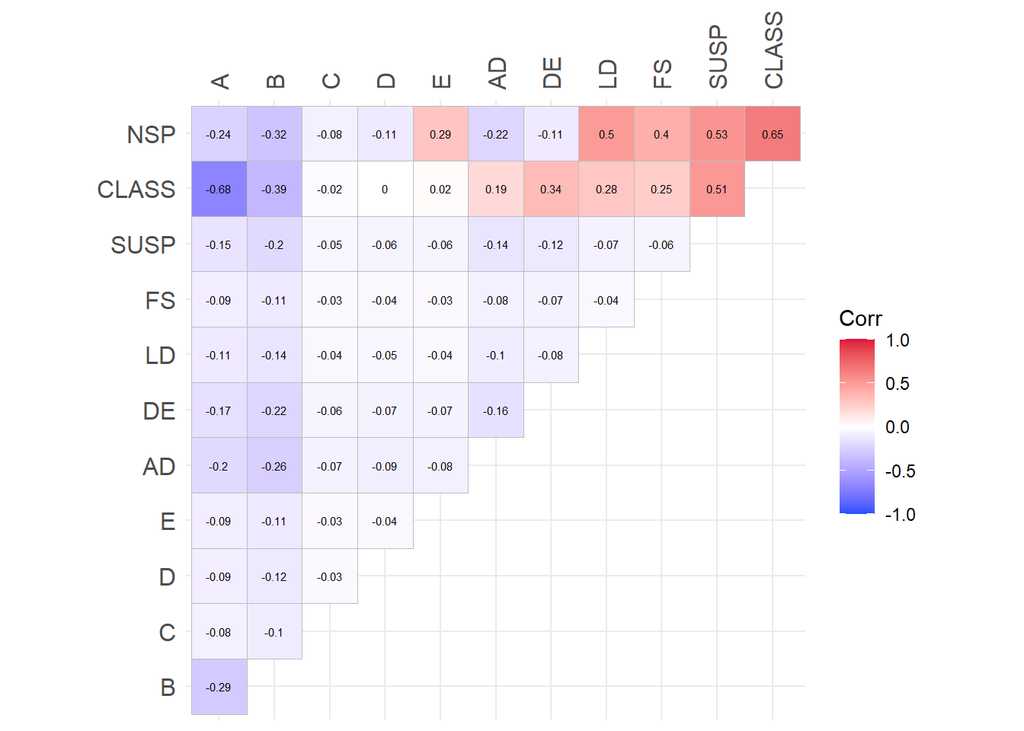

```r
model.matrix(~0+., data=morpho_data) %>%
  cor(use="pairwise.complete.obs", method = 'spearman') %>%
  ggcorrplot(show.diag = F, type="upper", lab=TRUE, lab_size=2, tl.srt = 90, colors = c( "#1F51FF", "white","#DC143C"))+
  scale_x_discrete(position='top')+
  theme( axis.text.x.top = element_text(angle = 90,hjust = 0,vjust = 0.5))
```

## kruskal test on the machine dataset, see most affected variables by NSP class

```r
library(broom)
no_norm_df_machine <- subset (no_norm_df, select = -c(A, B, C, D, E, AD, DE, LD, FS, SUSP, CLASS))

kwt_df <- no_norm_df_machine %>% gather(key, value, -NSP) %>%
       group_by(key) %>%
       do(tidy(kruskal.test(x= .$value, g = .$NSP)))

kwt_df[with(kwt_df, order(p.value, statistic)), ]
```

```
## # A tibble: 22 x 5
## # Groups:   key [22]
##    key      statistic   p.value parameter method
##    <chr>        <dbl>     <dbl>     <int> <chr>
##  1 DP            538. 1.17e-117         2 Kruskal-Wallis rank sum test
##  2 ASTV          533. 1.46e-116         2 Kruskal-Wallis rank sum test
##  3 AC            441. 1.37e- 96         2 Kruskal-Wallis rank sum test
##  4 MSTV          383. 5.83e- 84         2 Kruskal-Wallis rank sum test
##  5 ALTV          367. 1.78e- 80         2 Kruskal-Wallis rank sum test
##  6 LB            254. 5.92e- 56         2 Kruskal-Wallis rank sum test
##  7 Median        189. 9.89e- 42         2 Kruskal-Wallis rank sum test
##  8 UC            160. 2.13e- 35         2 Kruskal-Wallis rank sum test
##  9 Mean          153. 5.61e- 34         2 Kruskal-Wallis rank sum test
## 10 Variance      140. 5.00e- 31         2 Kruskal-Wallis rank sum test
## # ... with 12 more rows
```

```r
#str(no_norm_df_machine)
```

## kruskal test on the machine dataset, see least affected variables by NSP class

```r
kwt_df[with(kwt_df, order(-p.value, statistic)), ]
```

```
## # A tibble: 22 x 5
## # Groups:   key [22]
##    key      statistic  p.value parameter method
##    <chr>        <dbl>    <dbl>     <int> <chr>
##  1 nPoints       5.75 5.63e- 2         2 Kruskal-Wallis rank sum test
##  2 Max           8.82 1.22e- 2         2 Kruskal-Wallis rank sum test
##  3 Nzeros       12.2  2.26e- 3         2 Kruskal-Wallis rank sum test
##  4 FM           16.3  2.83e- 4         2 Kruskal-Wallis rank sum test
##  5 Min          22.0  1.70e- 5         2 Kruskal-Wallis rank sum test
##  6 Nmax         49.4  1.87e-11         2 Kruskal-Wallis rank sum test
##  7 Width        52.1  4.93e-12         2 Kruskal-Wallis rank sum test
##  8 DS           55.5  9.04e-13         2 Kruskal-Wallis rank sum test
##  9 Tendency     71.3  3.22e-16         2 Kruskal-Wallis rank sum test
## 10 MLTV         86.6  1.58e-19         2 Kruskal-Wallis rank sum test
## # ... with 12 more rows
```

##class imbalance analysis for the whole dataset

```r
#class imbalance analysis for the whole dataset

C<-3

Tdata<-length(no_norm_df$NSP)

n1<-length(which(no_norm_df$NSP=="1"))
n2<-length(which(no_norm_df$NSP=="2"))
n3<-length(which(no_norm_df$NSP=="3"))

imbalanceStat<-abs(((1/C)-(n1/Tdata)))+abs(((1/C)-(n2/Tdata)))+abs(((1/C)-(n3/Tdata)))

cat("Class 1: ",round(n1*100/Tdata,0),"%\n")
```

```
## Class 1:  78 %
```

```r
cat("Class 2: ",round(n2*100/Tdata,0),"%\n")
```

```
## Class 2:  14 %
```

```r
cat("Class 3: ",round(n3*100/Tdata,0),"%\n\n")
```

```
## Class 3:  8 %
```

```r
cat("Imbalance: ",round(imbalanceStat,2))
```

```
## Imbalance:  0.89
```

#————————————————————————–

## plotting the out put of the train test split in python thi section must run after the python script has produced the outputs

```r
# importing the python train test split for plotting

train_pthn <- read.csv(file = 'X_y_train_combined.csv', )
test_pthn <- read.csv(file = 'X_y_test_combined.csv', )

names <- c('Tendency', 'A', 'B',    'C',    'D',    'E',    'AD',   'DE',   'LD',   'FS',   'SUSP', 'CLASS', 'NSP')
train_pthn[,names] <- lapply(train_pthn[,names] , factor)
test_pthn[,names] <- lapply(test_pthn[,names] , factor)

#head(test_pthn)
```

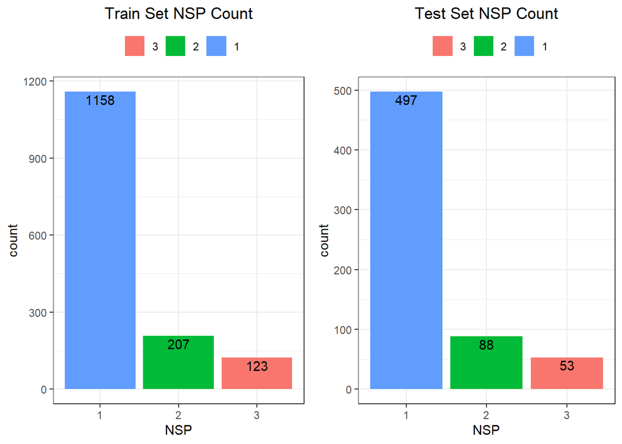

```r
library(ggplot2)
library(gridExtra)
 theme_set(
   theme_bw() +
     theme(legend.title=element_blank())+
     theme(legend.position = "top")
   )

p<-list()
p[[1]] <- ggplot(train_pthn, aes(x=NSP)) +
    geom_bar(aes(fill=factor(NSP, levels=c("3", "2", "1"))))+
  geom_text(stat='count', aes(label=..count..), vjust=1.25)+
  ggtitle("Train Set NSP Count")+
  theme(plot.title = element_text(hjust = 0.5))
p[[2]] <- ggplot(test_pthn, aes(x=NSP)) +
  geom_bar(aes(fill=factor(NSP, levels=c("3", "2", "1"))))+
  geom_text(stat='count', aes(label=..count..), vjust=1.25)+
  ggtitle("Test Set NSP Count")+
  theme(plot.title = element_text(hjust = 0.5))
grid.arrange(grobs=p,ncol=2, nrow=1)
```

##Importing the results of the classification models from python, decision tree, randome forest, and SVC

```r
# importing the python train test split for plotting

final_result <- read.csv(file = 'all_3_model_results.csv')


names <- c('sampling', 'model.name',    'normalization')
final_result[,names] <- lapply(final_result[,names] , factor)


head(final_result)
```

```
##                                              hyper_param_tuning
## 1                                                          none
## 2 {'random_state': 42, 'max_depth': 12, 'criterion': 'entropy'}
## 3  {'random_state': 42, 'max_depth': 6, 'criterion': 'entropy'}
## 4 {'random_state': 42, 'max_depth': 12, 'criterion': 'entropy'}
## 5 {'random_state': 42, 'max_depth': 12, 'criterion': 'entropy'}
## 6 {'random_state': 42, 'max_depth': 12, 'criterion': 'entropy'}
##   validation.precision validation.recall validation.f1 validation.accuracy
## 1            1.0000000         1.0000000     1.0000000           0.9993280
## 2            0.8879808         0.8858974     0.8805100           0.9334664
## 3            0.9217766         0.8775641     0.8957599           0.9348132
## 4            0.6972314         0.9282051     0.7926006           0.8568792
## 5            0.8725092         0.8858974     0.8760077           0.9314620
## 6            0.8513058         0.8858974     0.8653571           0.9301243
##   test.precision test.recall   test.f1 test.accuracy sampling
```

[output cut: 27 more lines]

## organizing result data to plot for accuracy of the results

```r
library(reshape2)
val_acc<- final_result[, c('test.imbalance', 'validation.accuracy','normalization', 'sampling', 'model.name')]

val_acc$procedure<-as.factor('validation')
names(val_acc)[names(val_acc) == 'validation.accuracy'] <- 'proc_accuracy'

test_acc<- final_result[, c('test.imbalance', 'test.accuracy','normalization', 'sampling', 'model.name')]

test_acc$procedure<-as.factor('test')
names(test_acc)[names(test_acc) == 'test.accuracy'] <- 'proc_accuracy'


acc<-rbind(val_acc, test_acc)
meltdf_acc<-melt(acc, id.var = c('test.imbalance','normalization', 'sampling', 'model.name', 'procedure'), variable.name = 'accuracy')

meltdf_acc_norm<-meltdf_acc[meltdf_acc$normalization=='norm',]
meltdf_acc_nonorm<-meltdf_acc[meltdf_acc$normalization=='no_norm',]

head(meltdf_acc_norm)
```

```
##    test.imbalance normalization sampling             model.name  procedure
## 49     0.88978495          norm     none DecisionTreeClassifier validation
## 50     0.88978495          norm  SMOTENC DecisionTreeClassifier validation
## 51     0.88978495          norm      ros DecisionTreeClassifier validation
## 52     0.09671848          norm  rus-ros DecisionTreeClassifier validation
## 53     0.68978495          norm  SMOTENC DecisionTreeClassifier validation
## 54     0.68978495          norm      ros DecisionTreeClassifier validation
##         accuracy     value
## 49 proc_accuracy 0.9993280
## 50 proc_accuracy 0.9321195
## 51 proc_accuracy 0.9294214
## 52 proc_accuracy 0.8581671
## 53 proc_accuracy 0.9166470
## 54 proc_accuracy 0.9274125
```

## plotting accuracy of validation and test data as a function of other variables

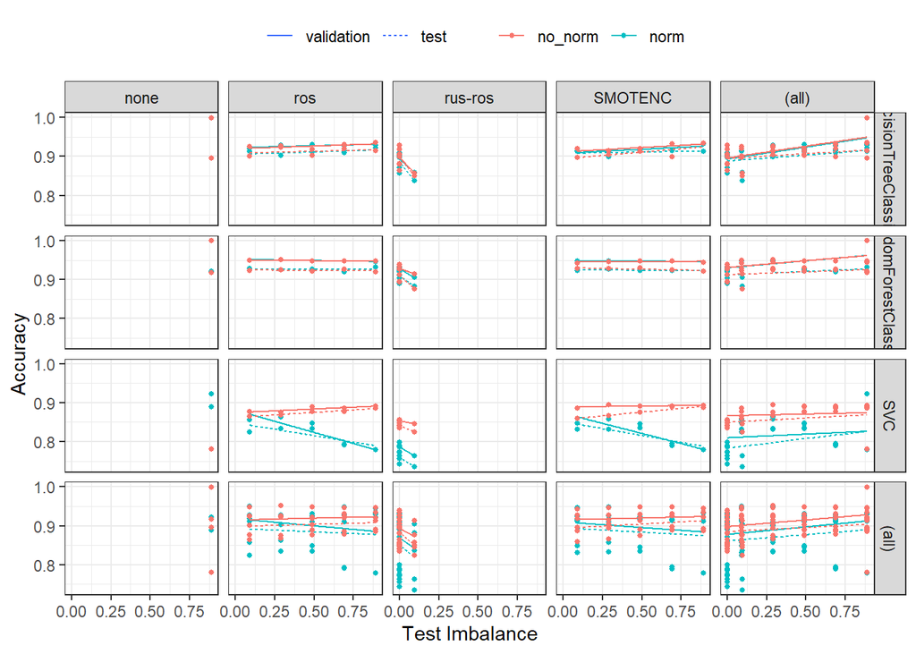

```r
library(reshape2)

ggplot(data=meltdf_acc_norm, aes(x=test.imbalance, y=value, col = normalization, group=procedure,linetype=procedure)) +

    geom_point(size=1) +
    geom_smooth(method=lm, se=FALSE, size=0.5)+

    geom_point(data=meltdf_acc_nonorm,, size=1) +
    geom_smooth(data=meltdf_acc_nonorm,method=lm, se=FALSE, size=0.5)+
    facet_grid(model.name ~ sampling, margins=TRUE)+

    xlab('Test Imbalance')+
    ylab("Accuracy")
```

## reorganizing data to plot the f1 score of class 3 for each classification model and balancing techniques and values

```r
val_f1<- final_result[, c('test.imbalance', 'validation.f1','normalization', 'sampling', 'model.name')]

val_f1$procedure<-as.factor('validation')
names(val_f1)[names(val_f1) == 'validation.f1'] <- 'proc_f1'

test_f1<- final_result[, c('test.imbalance', 'test.f1','normalization', 'sampling', 'model.name')]

test_f1$procedure<-as.factor('test')
names(test_f1)[names(test_f1) == 'test.f1'] <- 'proc_f1'


f1<-rbind(val_f1, test_f1)

meltdf_f1<-melt(f1, id.var = c('test.imbalance','normalization', 'sampling', 'model.name', 'procedure'), variable.name = 'f1')

meltdf_f1_norm<-meltdf_f1[meltdf_f1$normalization=='norm',]
meltdf_f1_nonorm<-meltdf_f1[meltdf_f1$normalization=='no_norm',]

head(meltdf_f1_norm)
```

```
##    test.imbalance normalization sampling             model.name  procedure
## 49     0.88978495          norm     none DecisionTreeClassifier validation
## 50     0.88978495          norm  SMOTENC DecisionTreeClassifier validation
## 51     0.88978495          norm      ros DecisionTreeClassifier validation
## 52     0.09671848          norm  rus-ros DecisionTreeClassifier validation
## 53     0.68978495          norm  SMOTENC DecisionTreeClassifier validation
## 54     0.68978495          norm      ros DecisionTreeClassifier validation
##         f1     value
## 49 proc_f1 1.0000000
## 50 proc_f1 0.8964320
## 51 proc_f1 0.8704541
## 52 proc_f1 0.8257880
## 53 proc_f1 0.8592041
## 54 proc_f1 0.8772383
```

## plot of f1 score for class 3 for each of the models and upsampling methods and imbalances

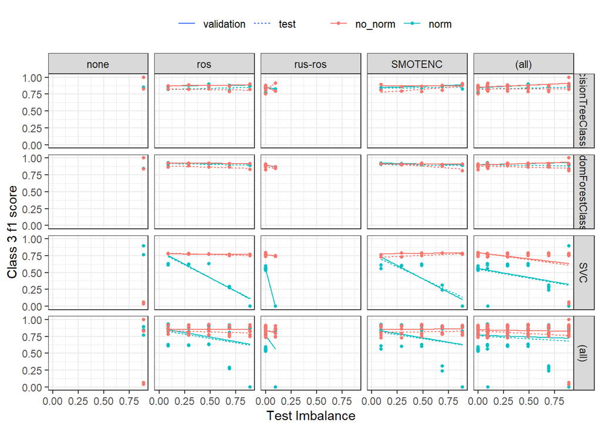

```r
ggplot(data=meltdf_f1_norm, aes(x=test.imbalance, y=value, col = normalization, group=procedure,linetype=procedure)) +

    geom_point(size=1) +
    geom_smooth(method=lm, se=FALSE, size=0.5)+

    geom_point(data=meltdf_f1_nonorm,, size=1) +
    geom_smooth(data=meltdf_f1_nonorm,method=lm, se=FALSE, size=0.5)+
    facet_grid(model.name ~ sampling, margins=TRUE)+

    xlab('Test Imbalance')+
    ylab("Class 3 f1 score")
```

## arrangind data to show the time taken in each step

```r
val_time<- final_result[, c('test.imbalance', 'validation.f1','normalization', 'sampling', 'model.name', 'time')]

val_time$procedure<-as.factor('validation')
names(val_time)[names(val_time) == 'validation.f1'] <- 'proc'

test_time<- final_result[, c('test.imbalance', 'test.f1','normalization', 'sampling', 'model.name', 'time')]

test_time$procedure<-as.factor('test')
names(test_time)[names(test_time) == 'test.f1'] <- 'proc'


time_df<-rbind(val_time, test_time)
time_df <- subset(time_df, select = -c(proc) )

meltdf_time<-melt(time_df, id.var = c('test.imbalance','normalization', 'sampling', 'model.name', 'procedure'), variable.name = 'time')

meltdf_time_norm<-meltdf_time[meltdf_time$normalization=='norm',]
meltdf_time_nonorm<-meltdf_time[meltdf_time$normalization=='no_norm',]

head(meltdf_time_norm)
```

```
##    test.imbalance normalization sampling             model.name  procedure time
## 49     0.88978495          norm     none DecisionTreeClassifier validation time
## 50     0.88978495          norm  SMOTENC DecisionTreeClassifier validation time
## 51     0.88978495          norm      ros DecisionTreeClassifier validation time
## 52     0.09671848          norm  rus-ros DecisionTreeClassifier validation time
## 53     0.68978495          norm  SMOTENC DecisionTreeClassifier validation time
## 54     0.68978495          norm      ros DecisionTreeClassifier validation time
##         value
## 49 0.02329445
## 50 2.40186572
## 51 0.53975272
## 52 0.44020557
## 53 2.49057293
## 54 0.53563213
```

## plot of time taken as a function of other variables

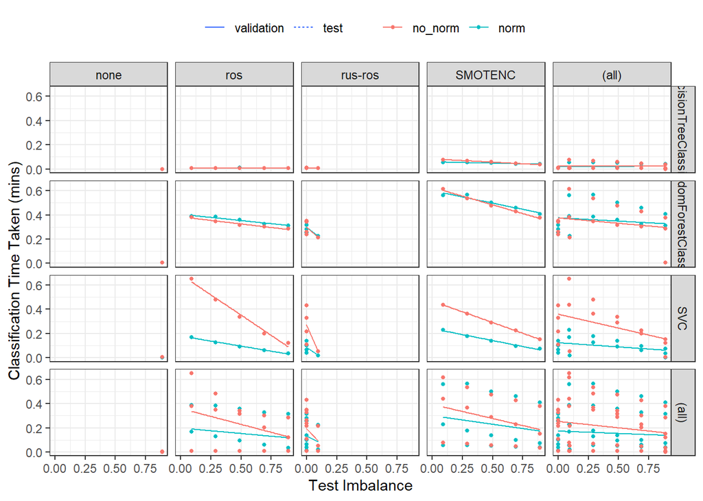

```r
ggplot(data=meltdf_time_norm, aes(x=test.imbalance, y=value/60, col = normalization, group=procedure,linetype=procedure)) +

    geom_point(size=1) +
    geom_smooth(method=lm, se=FALSE, size=0.5)+

    geom_point(data=meltdf_time_nonorm,, size=1) +
    geom_smooth(data=meltdf_time_nonorm,method=lm, se=FALSE, size=0.5)+
    facet_grid(model.name ~ sampling, margins=TRUE)+

    xlab('Test Imbalance')+
    ylab("Classification Time Taken (mins)")
```

## future work investigating the relations of the FS parameter

```r
describeBy(no_norm_df, group="FS")
```

```
##
##  Descriptive statistics by group
## FS: 0
##           vars    n   mean     sd median trimmed    mad   min    max  range
## LB           1 2057 133.18   9.80  133.0  133.15  10.38 106.0  160.0   54.0
## AC           2 2057   2.81   3.58    1.0    2.15   1.48   0.0   26.0   26.0
## FM           3 2057   7.27  37.57    0.0    1.03   0.00   0.0  564.0  564.0
## UC           4 2057   3.77   2.83    3.0    3.54   2.97   0.0   23.0   23.0
## ASTV         5 2057  46.02  16.57   47.0   46.06  20.76  12.0   83.0   71.0
## MSTV         6 2057   1.37   0.88    1.2    1.25   0.74   0.2    7.0    6.8
## ALTV         7 2057   8.24  15.51    0.0    4.25   0.00   0.0   73.0   73.0
## MLTV         8 2057   8.30   5.67    7.5    7.83   4.60   0.0   50.7   50.7
## DL           9 2057   1.62   2.52    0.0    1.09   0.00   0.0   16.0   16.0
## DS          10 2057   0.00   0.06    0.0    0.00   0.00   0.0    1.0    1.0
## DP          11 2057   0.13   0.47    0.0    0.00   0.00   0.0    4.0    4.0
## Width       12 2057  71.99  38.45   70.0   70.24  45.96   8.0  180.0  172.0
## Min         13 2057  92.63  29.30   91.0   91.85  38.55  50.0  159.0  109.0
## Max         14 2057 164.62  17.76  163.0  163.66  16.31 122.0  238.0  116.0
## Nmax        15 2057   4.16   2.95    4.0    3.86   2.97   0.0   18.0   18.0
## Nzeros      16 2057   0.33   0.72    0.0    0.18   0.00   0.0   10.0   10.0
## Mode        17 2057 137.46  16.49  139.0  138.52  14.83  60.0  187.0  127.0
## Mean        18 2057 134.51  15.71  136.0  135.41  14.83  73.0  182.0  109.0
## Median      19 2057 138.06  14.56  139.0  138.71  14.83  77.0  186.0  109.0
## Variance    20 2057  19.34  29.24    8.0   12.88  10.38   0.0  269.0  269.0
## nPoints     21 2057 829.12 304.81  808.0  821.83 303.93 163.0 3599.0 3436.0
## Tendency*   22 2057   2.32   0.61    2.0    2.37   0.00   1.0    3.0    2.0
## A*          23 2057   1.19   0.39    1.0    1.11   0.00   1.0    2.0    1.0
## B*          24 2057   1.28   0.45    1.0    1.23   0.00   1.0    2.0    1.0
## C*          25 2057   1.03   0.16    1.0    1.00   0.00   1.0    2.0    1.0
## D*          26 2057   1.04   0.19    1.0    1.00   0.00   1.0    2.0    1.0
## E*          27 2057   1.04   0.18    1.0    1.00   0.00   1.0    2.0    1.0
## AD*         28 2057   1.16   0.37    1.0    1.08   0.00   1.0    2.0    1.0
## DE*         29 2057   1.12   0.33    1.0    1.03   0.00   1.0    2.0    1.0
## LD*         30 2057   1.05   0.22    1.0    1.00   0.00   1.0    2.0    1.0
## FS*         31 2057   1.00   0.00    1.0    1.00   0.00   1.0    1.0    0.0
## SUSP*       32 2057   1.10   0.29    1.0    1.00   0.00   1.0    2.0    1.0
## CLASS*      33 2057   4.36   2.96    4.0    4.09   2.97   1.0   10.0    9.0
## NSP*        34 2057   1.25   0.54    1.0    1.12   0.00   1.0    3.0    2.0
##            skew kurtosis   se
## LB         0.02    -0.26 0.22
```

[output cut: 90 more lines]

```
## Variance     21.94  1.37
## nPoints      -0.40 33.72
## Tendency*    -0.74  0.08
## A*             NaN  0.00
## B*             NaN  0.00
## C*             NaN  0.00
## D*             NaN  0.00
## E*             NaN  0.00
## AD*            NaN  0.00
## DE*            NaN  0.00
## LD*            NaN  0.00
## FS*            NaN  0.00
## SUSP*          NaN  0.00
## CLASS*         NaN  0.00
## NSP*         62.09  0.01
```